# Homework 01

## Question 1 (Least squares and matrix calculations)

Set the random seed to 43201. Generate $n=100$ observations with $p=5$ predictors according to

$$x_{ij}\overset{\mathrm{iid}}{\sim}N(0,1),
\qquad
\varepsilon_i\overset{\mathrm{iid}}{\sim}N(0,0.7^2),$$

with all predictors and errors generated independently. Let

$$\mathbf X
=
\begin{bmatrix}
\mathbf 1 & \mathbf x_1 & \cdots & \mathbf x_5
\end{bmatrix},
\qquad
\boldsymbol\beta
=
(3,1.4,-0.9,0.7,0,1.1)^{\mathsf T},$$

and generate

$$\mathbf y=\mathbf X\boldsymbol\beta+\boldsymbol\varepsilon.$$

1. Generate the data and report the dimensions and rank of $\mathbf X$. Calculate the least-squares estimate $\widehat{\boldsymbol\beta}$ using a numerically stable least-squares routine, without explicitly calculating $(\mathbf X^{\mathsf T}\mathbf X)^{-1}$. Compare the estimates with the coefficients used to generate the data.
2. Calculate the fitted values, the residual vector $\mathbf r=\mathbf y-\mathbf X\widehat{\boldsymbol\beta}$, and the training root mean squared error

$$\operatorname{RMSE}
=
\left(
\frac{1}{n}\sum_{i=1}^{n}r_i^2
\right)^{1/2}.$$

3. Report $\lVert\mathbf X^{\mathsf T}\mathbf r\rVert_\infty$. Explain why this value should be close to zero and what it tells us about the residual vector.

#Q1 Answer

```r
set.seed(43201)

n <- 100
p <- 5

# Generate the five predictors
x <- matrix(rnorm(n * p), nrow = n, ncol = p)
colnames(x) <- paste0("x", seq_len(p))

# Add the intercept column
X <- cbind("(Intercept)" = 1, x)

beta <- c(
  "(Intercept)" = 3,
  x1 = 1.4,
  x2 = -0.9,
  x3 = 0.7,
  x4 = 0,
  x5 = 1.1
)

epsilon <- rnorm(n, mean = 0, sd = 0.7)
y <- as.vector(X %*% beta + epsilon)

# a
least_squares_fit <- lm.fit(x = X, y = y)
beta_hat <- least_squares_fit$coefficients

coefficient_comparison <- data.frame(
  coefficient = names(beta),
  truth = unname(beta),
  estimate = unname(beta_hat)
)

print(dim(X))
```

```
[1] 100   6
```

```r
print(qr(X)$rank)
```

```
[1] 6
```

```r
print(coefficient_comparison)
```

```
  coefficient truth   estimate
1 (Intercept)   3.0  3.0063210
2          x1   1.4  1.4171604
3          x2  -0.9 -0.8883453
4          x3   0.7  0.7952834
5          x4   0.0  0.0484378
6          x5   1.1  1.1319341
```

```r
#b
fitted_values <- as.vector(X %*% beta_hat)
residuals <- y - fitted_values
training_rmse <- sqrt(mean(residuals^2))
print(training_rmse)
```

```
[1] 0.6763696
```

```r
#c
normal_equation_error <- max(abs(crossprod(X, residuals)))
print(normal_equation_error)
```

```
[1] 5.878631e-14
```

## Question 2 (Gaussian likelihood for linear regression)

Continue with the data from Question 1. Suppose

$$\mathbf Y\mid\mathbf X
\sim
N_n\left(\mathbf X\boldsymbol\beta,\sigma^2\mathbf I_n\right).$$

The log-likelihood, including the constant term, is

$$\ell(\boldsymbol\beta,\sigma^2)
=
-\frac{n}{2}\log(2\pi\sigma^2)
-\frac{1}{2\sigma^2}
(\mathbf y-\mathbf X\boldsymbol\beta)^{\mathsf T}
(\mathbf y-\mathbf X\boldsymbol\beta).$$

1. For fixed $\sigma^2$, explain why maximizing $\ell(\boldsymbol\beta,\sigma^2)$ over $\boldsymbol\beta$ is equivalent to minimizing the residual sum of squares. What does this imply about the maximum-likelihood estimate of $\boldsymbol\beta$?
2. For fixed $\boldsymbol\beta$, differentiate the log-likelihood with respect to $\sigma^2$ and derive its maximum-likelihood estimate. Calculate this estimate at $\widehat{\boldsymbol\beta}$ and compare it with the unbiased estimate of $\sigma^2$. Explain why the two denominators differ.
3. Let

$$\mathbf e_{x_2}=(0,0,1,0,0,0)^{\mathsf T}.$$

Using the variance estimate from part b, plot

$$\ell\left(
\widehat{\boldsymbol\beta}+t\mathbf e_{x_2},
\widehat{\sigma}_{\mathrm{MLE}}^2
\right)$$

over a grid of $t$ values from $-1.25$ to $1.25$. State where the maximum occurs and explain why this agrees with the least-squares result.

#Q2 Answer #a For fixed (^2), the first term in the log-likelihood does not depend on (), and the coefficient multiplying the residual sum of squares is a negative constant. Therefore, maximizing the log-likelihood with respect to () is equivalent to minimizing the residual sum of squares. Hence, the maximum-likelihood estimate of () is the ordinary least-squares estimate.

#b

```r
rss <- sum(residuals^2)

sigma2_mle <- rss / n
sigma2_unbiased <- rss / (n - ncol(X))
```

Let (v=^2). Then

$$\ell(\beta,v)
=
-\frac{n}{2}\log(2\pi v)
-\frac{RSS}{2v}.$$

Differentiating with respect to (v),

$$\frac{\partial \ell}{\partial v}
=
-\frac{n}{2v}
+
\frac{RSS}{2v^2}.$$

Setting this equal to zero gives

$$\widehat{\sigma}_{MLE}^2
=
\frac{RSS}{n}.$$
For these data, the MLE is approximately 0.4575. The unbiased estimate is approximately 0.4867, using the denominator (n-6=94). The MLE uses n because it maximizes the likelihood directly, whereas the unbiased estimator adjusts for the six regression coefficients estimated from the data.

#c

```r
rss <- sum(residuals^2)

sigma2_mle <- rss / n
sigma2_unbiased <- rss / (n - ncol(X))

log_likelihood <- function(beta_value, sigma2, X, y) {
  residual <- y - as.vector(X %*% beta_value)
  -nrow(X) / 2 * log(2 * pi * sigma2) -
    sum(residual^2) / (2 * sigma2)
}

e_x2 <- c(0, 0, 1, 0, 0, 0)
t_grid <- seq(-1.25, 1.25, length.out = 251)

profile_log_likelihood <- vapply(
  t_grid,
  function(t) {
    log_likelihood(
      beta_hat + t * e_x2,
      sigma2_mle,
      X,
      y
    )
  },
  numeric(1)
)

print(c(
  sigma2_mle = sigma2_mle,
  sigma2_unbiased = sigma2_unbiased,
  maximizing_t = t_grid[which.max(profile_log_likelihood)]
))
```

```
     sigma2_mle sigma2_unbiased    maximizing_t
      0.4574759       0.4866765       0.0000000
```

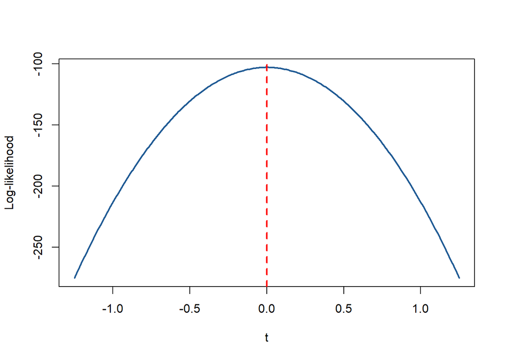

```r
plot(
  t_grid,
  profile_log_likelihood,
  type = "l",
  lwd = 2,
  col = "#1F5A94",
  xlab = expression(t),
  ylab = "Log-likelihood"
)
abline(
  v = 0,
  lty = 2,
  lwd = 2,
  col = "red"
)
```

The log-likelihood is maximized at (t=0). At this value, the coefficient vector is exactly (). Moving the (x_2) coefficient away from its least-squares estimate increases the residual sum of squares and therefore decreases the Gaussian log-likelihood. This agrees with the result in part a.

## Question 3 (Starting values in nonconvex optimization)

Consider the function

$$f(x)=\exp(1.5x)-3(x+6)^2-0.05x^3,$$

with derivative

$$f'(x)=1.5\exp(1.5x)-6(x+6)-0.15x^2.$$

1. Plot $f(x)$ over the interval $[-40,7]$. Based on the plot, describe the important features of the objective function that may affect numerical optimization.
2. Use BFGS to minimize $f(x)$ twice, starting at $x^{(0)}=-15$ and $x^{(0)}=0$. Supply $f'(x)$ to the optimizer. For each run, report the final value of $x$, the final objective value, $|f'(x)|$, and whether the optimizer reported convergence.
3. Explain why the two runs can converge to different answers. Which run gives the lower objective value? What additional evidence would be needed before claiming that this point is the global minimum?

#Q3 Answer

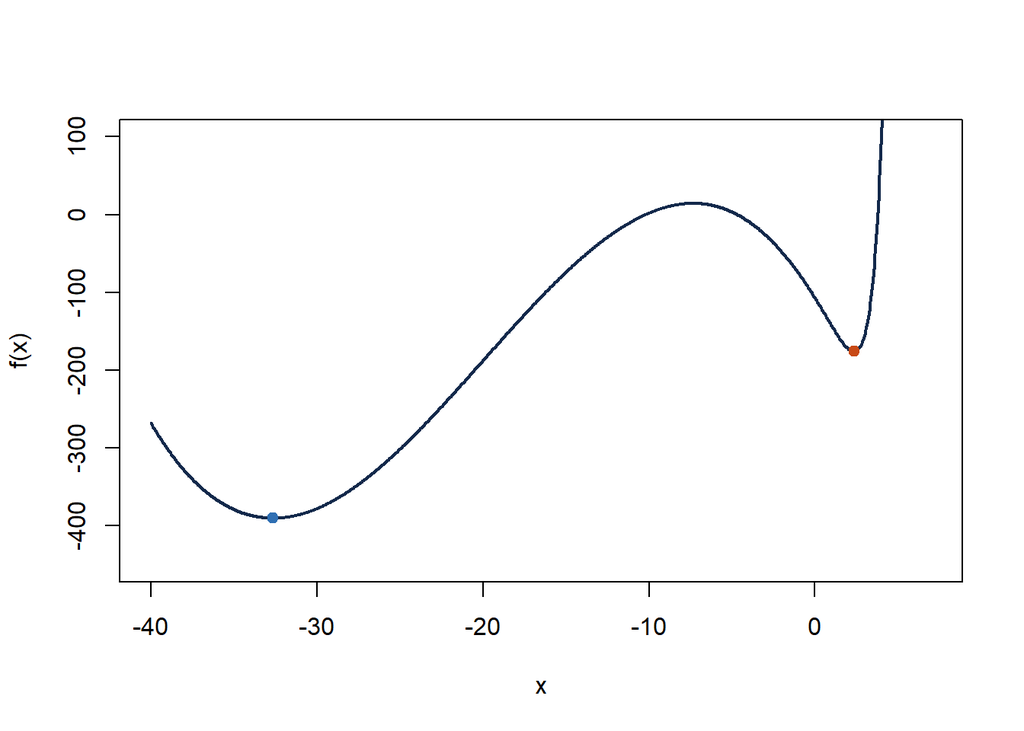

```r
objective <- function(x) {
  exp(1.5 * x) - 3 * (x + 6)^2 - 0.05 * x^3
}

gradient <- function(x) {
  1.5 * exp(1.5 * x) - 6 * (x + 6) - 0.15 * x^2
}

x_grid <- seq(-40, 7, length.out = 1200)

# Restrict only the displayed vertical range so both minima are visible.
plot(
  x_grid,
  objective(x_grid),
  type = "l",
  lwd = 2,
  col = "#13294B",
  ylim = c(-450, 100),
  xlab = "x",
  ylab = "f(x)"
)

starts <- c(-15, 0)
optimization_results <- lapply(
  starts,
  function(start) {
    optim(
      par = start,
      fn = objective,
      gr = gradient,
      method = "BFGS"
    )
  }
)

optimization_summary <- do.call(
  rbind,
  Map(
    function(start, result) {
      data.frame(
        starting_value = start,
        final_x = result$par,
        objective = result$value,
        absolute_gradient = abs(gradient(result$par)),
        converged = result$convergence == 0
      )
    },
    starts,
    optimization_results
  )
)

points(
  optimization_summary$final_x,
  optimization_summary$objective,
  pch = 19,
  col = c("#2F6FB3", "#C84A16")
)
```

```r
print(optimization_summary)
```

```
  starting_value    final_x objective absolute_gradient converged
1            -15 -32.649111 -390.3858      8.725087e-08      TRUE
2              0   2.349967 -175.8626      6.556057e-07      TRUE
```

#a The objective function is nonconvex and contains multiple stationary points. In particular, the plot suggests two distinct local minima separated by a local maximum. Therefore, a local optimization method such as BFGS may converge to different solutions depending on its starting value.

#b Starting at (x^{(0)}=-15), BFGS converges to approximately (x=-32.6491), with objective value -390.3858. Starting at (x^{(0)}=0), it converges to approximately (x=2.3500), with objective value -175.8626. In both cases the absolute gradient is close to zero and optim() reports convergence.

#c The run beginning at -15 gives the lower objective value. However, this alone does not establish global optimality. Stronger evidence would require identifying all stationary points, comparing their objective values, and examining the limiting behavior of (f(x)). Using many starting values can provide additional numerical evidence but does not by itself prove that the solution is global.

## Question 4 (Nearly collinear predictors)

Continue with $\mathbf X$ and $\mathbf y$ from Question 1. Set the random seed to 43202 and generate

$$u_i\overset{\mathrm{iid}}{\sim}N(0,1),
\qquad i=1,\ldots,n.$$

Define

$$\mathbf x_6=\mathbf x_1+10^{-4}\mathbf u,
\qquad
\mathbf X_+
=
\begin{bmatrix}
\mathbf X & \mathbf x_6
\end{bmatrix},$$

and let

$$\mathbf y^\star=\mathbf y+10^{-3}\mathbf u.$$

Use a numerically stable least-squares routine throughout.

1. Fit $\mathbf y$ using $\mathbf X$ and $\mathbf X_+$. For each design matrix, report the condition number and training RMSE. For the augmented fit, also report the coefficients of $\mathbf x_1$ and $\mathbf x_6$.
2. Fit $\mathbf y^\star$ using $\mathbf X_+$. Report the changes in the coefficients of $\mathbf x_1$ and $\mathbf x_6$. Compare the two fitted-value vectors using their root mean squared difference and maximum absolute difference.
3. Use the identity

$$\mathbf y^\star-\mathbf y
=
10(\mathbf x_6-\mathbf x_1)$$

to explain why the fitted values change very little while the two coefficients change substantially. What does this example suggest about interpreting separate effects for nearly collinear predictors?

#Q4 Answer

```r
set.seed(43202)
u <- rnorm(n)

x1 <- X[, "x1"]
x6 <- x1 + 1e-4 * u
X_plus <- cbind(X, x6 = x6)
y_star <- y + 1e-3 * u

fit_original <- lm.fit(x = X, y = y)
fit_augmented <- lm.fit(x = X_plus, y = y)
fit_perturbed <- lm.fit(x = X_plus, y = y_star)

beta_augmented <- fit_augmented$coefficients
beta_perturbed <- fit_perturbed$coefficients

fitted_augmented <- as.vector(X_plus %*% beta_augmented)
fitted_perturbed <- as.vector(X_plus %*% beta_perturbed)

condition_number <- function(design) {
  singular_values <- svd(design, nu = 0, nv = 0)$d
  max(singular_values) / min(singular_values)
}

fit_summary <- data.frame(
  design = c("X", "X_plus"),
  condition_number = c(
    condition_number(X),
    condition_number(X_plus)
  ),
  training_rmse = c(
    sqrt(mean(fit_original$residuals^2)),
    sqrt(mean(fit_augmented$residuals^2))
  )
)

coefficient_summary <- data.frame(
  response = c("y", "y_star"),
  beta_x1 = c(beta_augmented["x1"], beta_perturbed["x1"]),
  beta_x6 = c(beta_augmented["x6"], beta_perturbed["x6"])
)

coefficient_change <- (
  beta_perturbed[c("x1", "x6")] -
    beta_augmented[c("x1", "x6")]
)
fitted_difference <- fitted_perturbed - fitted_augmented

print(fit_summary)
```

```
  design condition_number training_rmse
1      X         1.524914     0.6763696
2 X_plus     20209.203501     0.6754668
```

```r
print(coefficient_summary)
```

```
  response  beta_x1   beta_x6
1        y 351.6766 -350.2588
2   y_star 341.6766 -340.2588
```

```r
print(coefficient_change)
```

```
 x1  x6
-10  10
```

```r
print(c(
  fitted_difference_rmse = sqrt(mean(fitted_difference^2)),
  fitted_difference_max = max(abs(fitted_difference))
))
```

```
fitted_difference_rmse  fitted_difference_max
           0.001015879            0.002572675
```

#a The condition number increases from approximately 1.52 for (X) to approximately (2.02^4) for (X_+), showing that the augmented design matrix is nearly collinear. The training RMSE changes only slightly, from about 0.6764 to 0.6755. However, the augmented-model coefficients for (x_1) and (x_6) are approximately 351.68 and -350.26, respectively, illustrating substantial coefficient instability.

#b After replacing (y) with (y^), the (x_1) coefficient decreases by approximately 10 while the (x_6) coefficient increases by approximately 10. Despite these large coefficient changes, the root mean squared difference between the two fitted-value vectors is only about 0.00102, and the maximum absolute difference is about 0.00257.

#c Because (x_6-x_1=10^{-4}u), the perturbation in the response can be written as
$$y^\star-y=10(x_6-x_1).$$
Thus, decreasing the (x_1) coefficient by 10 and increasing the (x_6) coefficient by 10 produces exactly this small change in the fitted values. The near equality of (x_1) and (x_6) therefore allows large offsetting coefficient changes with almost no change in prediction. This illustrates why separate coefficient interpretations are unreliable when predictors are nearly collinear.

## Question 5 (Data preparation and summary statistics)

The file `data/data-manipulation.csv` is a small constructed data table containing an observation identifier, a group label, two numeric predictors, and a response. Some response values are missing. For analyses involving the response, use only observations with a recorded response. Do not replace a missing response with zero or a group mean.

1. Read the data and report its dimensions, column types, number of duplicated identifiers, and number of missing values in each column. Create an analysis table containing only observations with a recorded response, and define

$$\texttt{feature\_sum}=\texttt{x1}+\texttt{x2}.$$

2. For each group, report the number of observations, the mean response, and the mean of `feature_sum`. State clearly which observations these summaries describe.
3. Sort the analysis table by response from largest to smallest and report the first three rows, including `observation_id`, `group`, `response`, and `feature_sum`. Add code checks verifying that the number of retained rows equals the number of nonmissing responses in the original data, that the analysis table has no missing response values, and that its identifiers are unique.

#Q5 Answer #a

```r
data_file <- file.path("data", "data-manipulation.csv")

if (!file.exists(data_file)) {
  document_dir <- Sys.getenv("QUARTO_DOCUMENT_PATH", unset = ".")
  data_file <- file.path(
    document_dir,
    "data",
    "data-manipulation.csv"
  )
}

small_data <- read.csv(
  data_file,
  stringsAsFactors = FALSE,
  check.names = FALSE
)

print(dim(small_data))
```

```
[1] 24  5
```

```r
print(vapply(
  small_data,
  class,
  character(1)
))
```

```
observation_id          group             x1             x2       response
   "character"    "character"      "numeric"      "numeric"      "numeric"
```

```r
print(c(
  duplicated_identifiers =
    sum(duplicated(small_data$observation_id))
))
```

```
duplicated_identifiers
                     0
```

```r
print(colSums(is.na(small_data)))
```

```
observation_id          group             x1             x2       response
             0              0              0              0              3
```

```r
# Keep only observations with recorded responses
analysis_data <- small_data[
  !is.na(small_data$response),
]

analysis_data$feature_sum <- (
  analysis_data$x1 + analysis_data$x2
)
```

The original dataset contains 24 observations and 5 variables. observation_id and group are character variables, while x1, x2, and response are numeric. There are no duplicated observation identifiers. Only response contains missing values, with 3 missing responses. After removing observations with missing responses, the analysis dataset contains 21 observations. The variable feature_sum was defined as x1 + x2.

#b

```r
group_summary <- do.call(
  rbind,
  lapply(
    split(analysis_data, analysis_data$group),
    function(group_data) {
      data.frame(
        group = group_data$group[1],
        observations = nrow(group_data),
        mean_response = mean(group_data$response),
        mean_feature_sum = mean(group_data$feature_sum),
        row.names = NULL
      )
    }
  )
)

print(group_summary)
```

```
  group observations mean_response mean_feature_sum
A     A            7      5.600000         3.600000
B     B            7      7.602857         4.928571
C     C            7      7.997143         6.585714
```

Among observations with recorded responses, Group A contains 7 observations, with a mean response of 5.6000 and a mean feature_sum of 3.6000. Group B contains 7 observations, with a mean response of 7.6029 and a mean feature_sum of 4.9286. Group C contains 7 observations, with a mean response of 7.9971 and a mean feature_sum of 6.5857. These summaries describe only the 21 observations with nonmissing response values.

#c

```r
largest_three <- analysis_data[
  order(
    analysis_data$response,
    decreasing = TRUE
  ),
  c(
    "observation_id",
    "group",
    "response",
    "feature_sum"
  )
][1:3, ]

print(largest_three)
```

```
   observation_id group response feature_sum
22         obs-22     C     9.24         6.6
16         obs-16     B     9.00         5.2
14         obs-14     B     8.66         5.0
```

```r
number_recorded <- sum(
  !is.na(small_data$response)
)

stopifnot(
  nrow(analysis_data) == number_recorded,
  !anyNA(analysis_data$response),
  !anyDuplicated(analysis_data$observation_id)
)
```

The three largest recorded responses are obs-22 from Group C with a response of 9.24 and feature_sum of 6.6, obs-16 from Group B with a response of 9.00 and feature_sum of 5.2, and obs-14 from Group B with a response of 8.66 and feature_sum of 5.0. The code checks confirm that the analysis dataset contains exactly all observations with recorded responses, contains no missing response values, and has unique observation identifiers.

## Question 6 (Can 39 million Fitbit records represent US adults?)

[Patten et al. (2026)](https://doi.org/10.1038/s41591-026-04352-3) describe Fitbit data from 59,018 participants in the All of Us Research Program. The dataset spans 14 years and contains more than 39 million daily step records. Participants contributed data through one of two routes:

- Bring Your Own Device (BYOD): participants shared data from a Fitbit they already owned.
- Wearables Enhancing All of Us Research (WEAR): invited participants received a Fitbit at no cost.

In the general activity cohort, the BYOD and WEAR groups contained 32,035 and 22,474 participants, respectively. The BYOD value is listed first in each comparison below:

- 77.3% versus 55.1% reported being White;
- 6.1% versus 15.2% reported annual household income between $\$10{,}000$ and $\$25{,}000$; and
- median daily steps were 6,867 versus 5,797.

Suppose the target is the mean of the participant-specific average daily step counts among US adults during the study period, with each adult given equal weight. A researcher writes:

> “This dataset contains more than 39 million daily Fitbit records. Therefore, the average of all recorded step counts should provide an accurate estimate of mean daily activity among US adults.”
1. Are the 39 million daily records independent observations? What characteristics or behaviors could cause some participants to contribute more recorded days than others? Explain how averaging all recorded days would then weight participants unequally. #Answer The 39 million daily records are not independent observations because many records come from the same participants. Daily activity measurements from the same person are likely to be correlated. Participants may also contribute different numbers of days because of differences in enrollment duration, device use, adherence, charging, syncing, or willingness to continue sharing data. A naive average over all recorded days weights participant (i) in proportion to the number of days (m_i) that person contributes. Thus, participants with more recorded days receive greater weight, whereas the target quantity gives each adult equal weight.
2. BYOD participants reported a median of 6,867 daily steps, compared with 5,797 among WEAR participants. Does this comparison show that already owning a Fitbit causes people to walk more? Explain your answer and give at least one plausible alternative explanation based on how participants entered the two groups. #Answer No. The difference in median daily steps does not establish that already owning a Fitbit causes greater physical activity. BYOD and WEAR participants were not randomly assigned to device ownership. BYOD participants had already chosen to purchase and use a Fitbit, whereas WEAR participants received one through the study. The groups may therefore differ in health consciousness, prior activity, socioeconomic characteristics, technology use, or other factors associated with physical activity. The observed difference is an association rather than a causal effect.
3. A very large dataset can still produce a biased estimate of a population quantity when the people and observations entering the dataset are selected. Using this study, explain how selection of both participants and recorded days could make the observed data differ from the US adult population. Why might the naive average of all recorded daily step counts fail to estimate the stated target? You do not need to determine the direction of the bias. #Answer A very large dataset can still be biased when entry into the dataset is selective. First, Fitbit contributors may differ systematically from the overall US adult population. BYOD participants in particular had already chosen to own and use a Fitbit, while participation in WEAR also depended on study recruitment and uptake. The demographic differences between the BYOD and WEAR groups illustrate that the mechanisms producing the observed sample are not random. Second, recorded days are also selected. Participants differ in how long and how consistently they wear, charge, and sync their devices, so some participants contribute substantially more observations than others. Missing or unrecorded days may also be systematically different from recorded days. Consequently, averaging all recorded daily step counts weights participants according to their number of observed days rather than giving each adult equal weight. It also represents selected Fitbit participants and selected recorded days rather than a random sample of US adults and their daily activity. Therefore, the naive average of all 39 million records need not estimate the stated population target, regardless of the very large number of observations.

### Source

Patten, T., Preble, E. A., Master, H., et al. (2026). [The All of Us Research Program’s wearables dataset](https://doi.org/10.1038/s41591-026-04352-3). *Nature Medicine*, 32, 2302-2310.